# Pearson Test

Ozgur Polat und Kathrin Einzmannt

08 01 2020

## Datensatz:

Var 1 = total bill (gezahlten Rechnung, ist intervallskaliert)

Var 2 = tip (Trinkgeld, ist intervallskaliert)

# 1. Hypothese:

H1: Es gibt einen Zusammenhang zwischen der gesamten Rechnung und dem Trinkgeld

H0: Es gibt keinen Zusammenhang zwischen der gesamten Rechnung und dem Trinkgeld

# 2. Voraussetzungen des Pearson-Tests

• Die Variablen sind mindestens intervallskaliert.

• Die Variablen sind normalverteilt (n>30)

• Der untersuchte Zusammenhang zwischen den Variablen muss linear sein.

# 3. Grundlegende Konzepte: Was ist Pearson?

Die Korrelation nach Bravais-Pearson gibt die Stärke der linearen Beziehung zwischen zwei intervallskalierten Variablen an. Der Korrelationskoeffizient gibt an, ob es eine positive, negative oder keine Beziehung gibt und in welcher Stärke die linearen Beziehung vorliegt. Der Korrelationskoeffizient r kann Werte zwischen -1 und +1 annehmen und ist unabhängig von der Maßeinheit. Ein Wert von -1 beschreibt eine perfekt negative Korrelation und ein Wert von +1 beschreibt eine perfekt positive Korrelation. Ist r = 0, besteht kein linearer Zusammenhang zwischen den Variablen. Da stets der Zusammenhang zwischen zwei Variablen untersucht wird, wird von einem “bivariaten Zusammenhang” gesprochen. Zwei Variablen hängen dann linear zusammen, wenn sie linear miteinander variieren (also kovariieren).

# 4. Grafische Veranschaulichung des Zusammenhangs

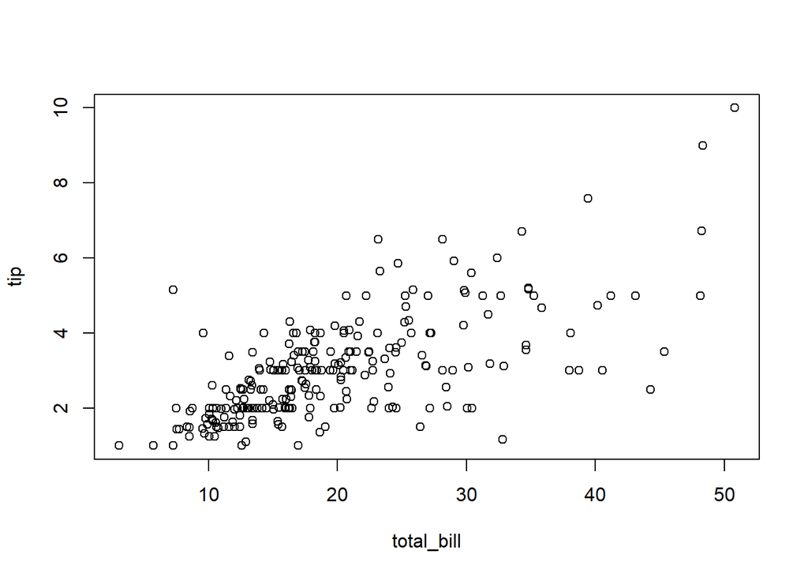

```r
plot(TIPS[2:3])
```

# Normalverteilung

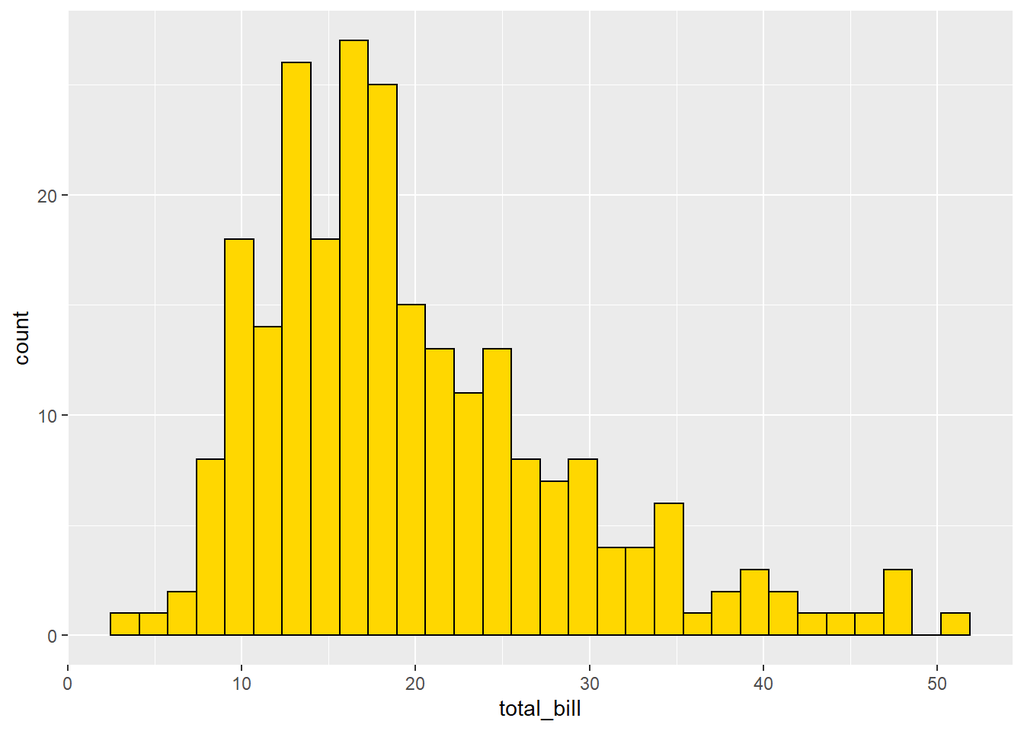

```r
library(reshape2)
library(ggplot2)

ggplot(TIPS, aes(x = total_bill)) +
geom_histogram(color = "black", fill = "gold")
```

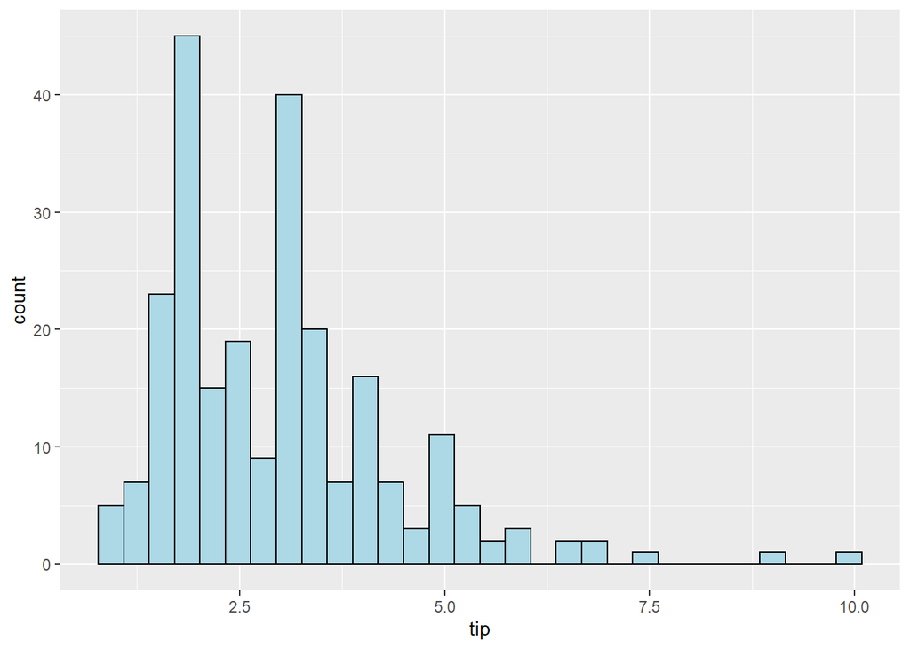

```r
ggplot(TIPS, aes(x = tip )) +
geom_histogram(color = "black", fill = "lightblue")
```

# Streudiagramm

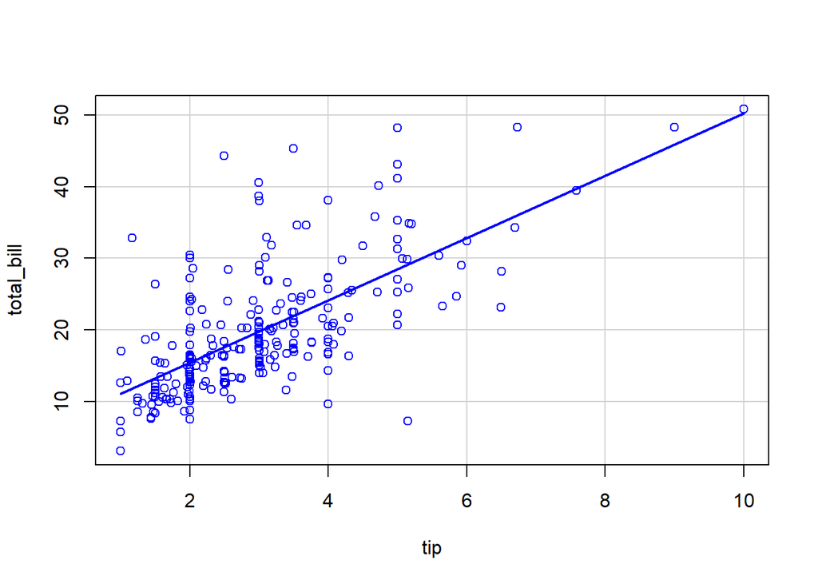

```r
scatterplot(total_bill~tip, regLine=TRUE, smooth=FALSE, boxplots=FALSE, jitter=list(x=1, y=1),
  by.groups=FALSE, data=TIPS)
```

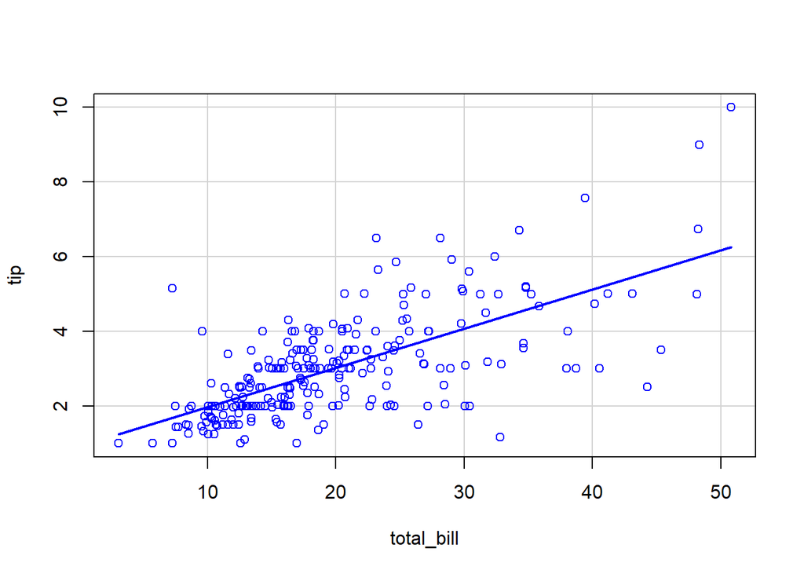

```r
scatterplot(tip~total_bill, regLine=TRUE, smooth=FALSE, boxplots=FALSE, jitter=list(x=1, y=1),
  by.groups=FALSE, data=TIPS)
```

Das Streudiagramm zeigt eine tendenziell positive lineare Beziehung zwischen den beiden Variablen.

Die Voraussetzungen sind gegeben:

• Variablen sind intervallskaliert

• Der untersuchte Zusammenhang zwischen den Variablen ist (positiv) linear.

# Boxplots

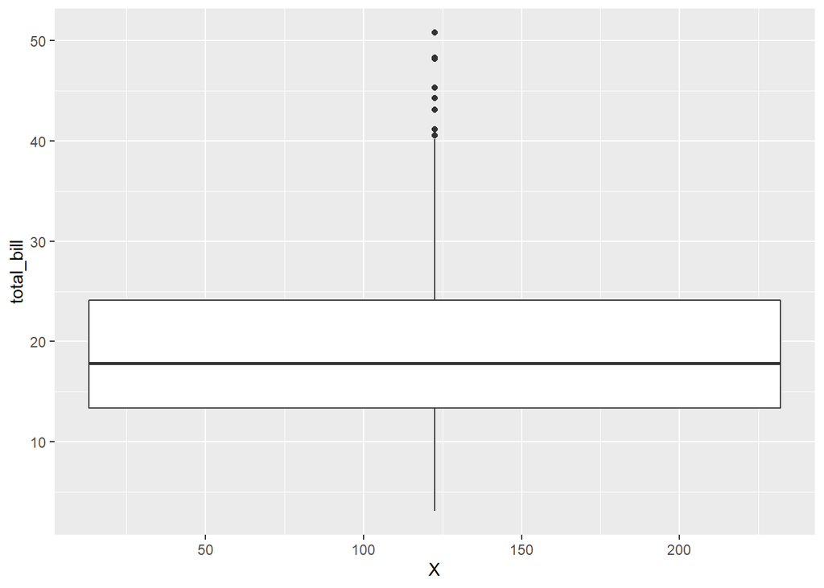

```r
ggplot(TIPS, aes(x=X, y = total_bill )) +
geom_boxplot()
```

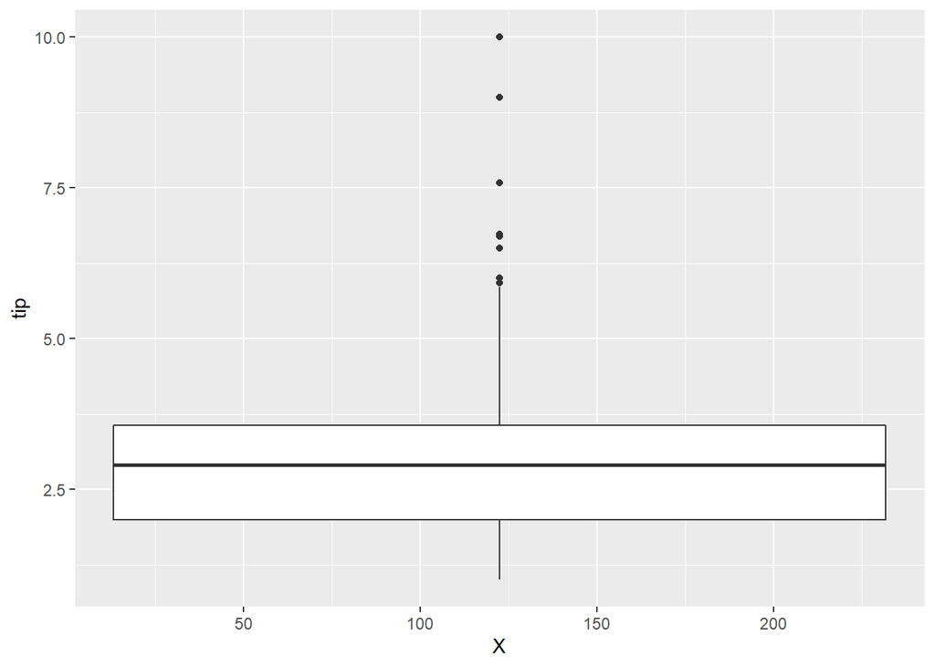

```r
ggplot(TIPS, aes(x=X, y = tip )) +
geom_boxplot()
```

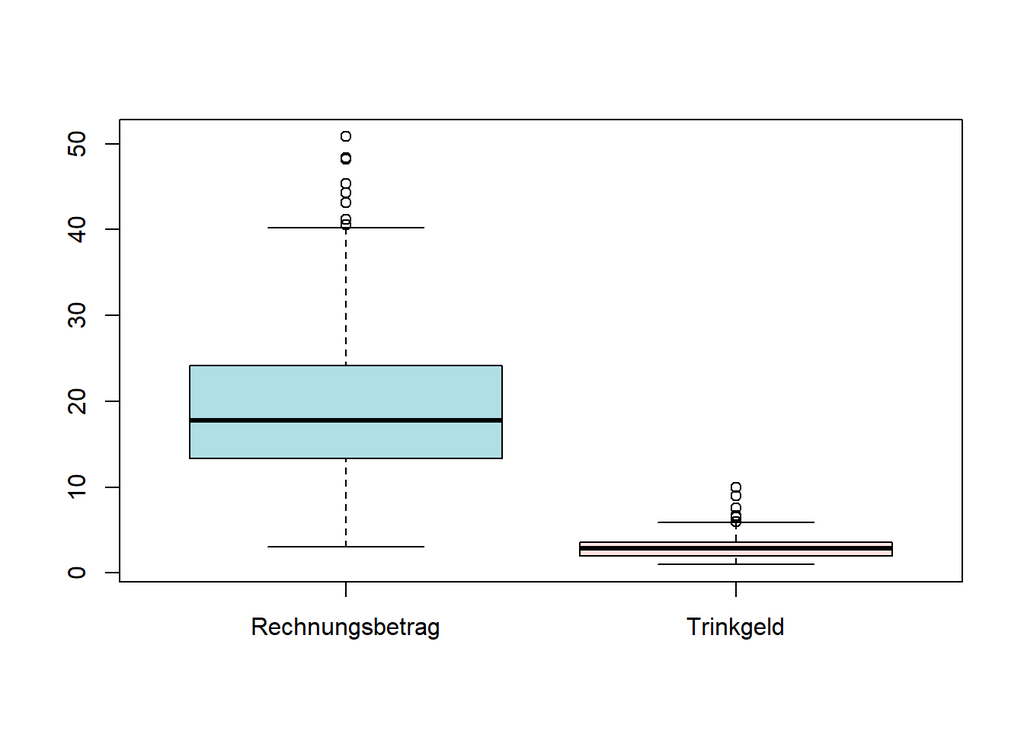

```r
boxplot(TIPS[2:3],names = c("Rechnungsbetrag","Trinkgeld"), col=c('powderblue', 'mistyrose'))
```

Der Boxplot zeigt, dass sowohl der Rechnungsbetrag als auch das Trinkgeld einige Ausreißer nach oben haben.

# 5. Deskriptive Statistik

```r
library(abind, pos=24)
library(e1071, pos=25)
numSummary(TIPS[,c("total_bill", "tip"), drop=FALSE], statistics=c("mean", "sd",
  "se(mean)", "IQR", "quantiles", "skewness", "kurtosis"), quantiles=c(0,.25,.5,.75,1), type="2")
```

```
##                 mean       sd   se(mean)     IQR skewness kurtosis   0%     25%
## total_bill 19.785943 8.902412 0.56991853 10.7800 1.133213 1.218484 3.07 13.3475
## tip         2.998279 1.383638 0.08857836  1.5625 1.465451 3.648376 1.00  2.0000
##               50%     75%  100%   n
## total_bill 17.795 24.1275 50.81 244
## tip         2.900  3.5625 10.00 244
```

Im Mittel liegt der Rechnungsbetrag bei $19,8 mit Standardabweichung von $8,9 und die Höhe des Trinkgeldes im Mittel bei $3,0 mit Standardabweichung von $1,4.

# 6. Ergebnisse der Korrelationsanalyse

## Correlation

```r
pearson_cr <- rcorr.adjust(TIPS[, c("total_bill", "tip")], type = "pearson", use = "complete")
pearson_cr
```

```
##
##  Pearson correlations:
##            total_bill    tip
## total_bill     1.0000 0.6757
## tip            0.6757 1.0000
##
##  Number of observations: 244
##
##  Pairwise two-sided p-values:
##            total_bill tip
## total_bill            <.0001
## tip        <.0001
##
##  Adjusted p-values (Holm's method)
##            total_bill tip
## total_bill            <.0001
## tip        <.0001
```

Es wird ersichtlich, dass ein Zusammenhang vorliegt zwischen dem Rechnungsbetrages und des Trinkgeldes (r = .676, p = .000, n = 244). Da r einen positiven Wert aufweist, kann von einem positiven linearen Zusammenhang ausgegangen werden. Das bedeutet: Je höher der Rechnungsbetrag, desto höher das Trinkgeld. Bzw. Je höher das Trinkgeld, desto höher der Rechnungsbetrag.

# 7. Berechnung des Bestimmtheitsmasses

```r
pearson_cr$R
```

```
##            total_bill  tip
## total_bill       1.00 0.68
## tip              0.68 1.00
##
## n= 244
##
##
## P
##            total_bill tip
## total_bill             0
## tip         0
```

```r
A <- pearson_cr$R[1]

r <- A$r[2,1]

r
```

```
## [1] 0.6757341
```

```r
r_sq <- A$r[2,1]^2

r_sq
```

```
## [1] 0.4566166
```

Aus der Korrelation lässt sich durch Quadrieren das Bestimmtheitsmass berechnen:

Bestimmtheitsmass = r²

Für das Beispiel ergibt dies:

r² = 0.6757^2 = 0.4566

Wird dieser Wert mit 100 multipliziert, so ergibt sich ein Prozentwert. Dieser gibt an, welcher Anteil der Varianz in beiden Variablen durch gemeinsame Varianzquellen determiniert wird. Für das vorliegende Beispiel beträgt der Anteil der gemeinsamen Varianz 45.66%.

# 8. Berechnung der Effektstärk

Um die Bedeutsamkeit eines Ergebnisses zu beurteilen, werden Effektstärken berechnet. Im Beispiel ist die Korrelation der beiden Variablen signifikant, doch es stellt sich die Frage, ob der Zusammenhang gross genug ist, um ihn als bedeutend einzustufen. Der Korrelationskoeffizient r von Bravais-Pearson stellt selbst ein Mass für die Effektstärke dar.

Um zu bestimmen, wie gross der gefundene Zusammenhang ist, kann man sich an der Einteilung von Cohen (1992) orientieren:

r = .10 entspricht einem schwachen Effekt

r = .30 entspricht einem mittleren Effekt

r = .50 entspricht einem starken Effekt

# 7. Aussage

Die alternative Hypothese kann akzeptiert werden. Die Nullhypothese wird abgelehnt.

Es wird ersichtlich, dass ein signifikanter Zusammenhang zwischen dem Rechnungsbetrag und dem Trinkgeld vorliegt (r = .676, p = .000, n = 244). Da r einen positiven Wert aufweist, kann von einem positiven linearen Zusammenhang ausgegangen werden. Das bedeutet: Je höher der Rechnungsbetrag, desto höher das Trinkgeld. Bzw. Je höher das Trinkgeld, desto höher der Rechnungsbetrag.

Im Mittel liegt der Rechnungsbetrag bei $19,8 mit Standardabweichung von $8,9 und die Höhe des Trinkgeldes im Mittel bei $3,0 mit Standardabweichung von $1,4.

Das Bestimmtheitsmass r² ist 0.46. Wird dieser Wert mit 100 multipliziert, so ergibt sich ein Prozentwert. Dieser gibt an, welcher Anteil der Varianz in beiden Variablen durch gemeinsame Varianzquellen determiniert wird. Für das vorliegende Beispiel beträgt der Anteil der gemeinsamen Varianz 45.66%.

Dabei handelt es sich nach Cohen (1992) um einen starken Effekt mit r= 0.68. Die alternative Hypothese kann akzeptiert werden. Die Nullhypothese wird abgelehnt.